# Assignment TP2

Manuela Giansante

2023-03-09

```r
rm(list = ls())
library(fpp3)
library(forecast)
library (ggplot2)
library(dplyr)
```

```r
#Load the data
data("global_economy")
```

### 1. Plot the Exports series for selected country and discuss the main features of the data.

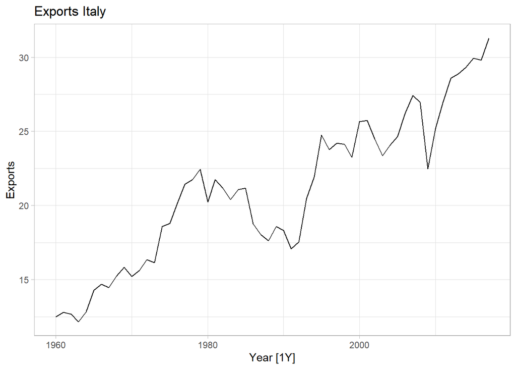

```r
# Plot out the time-series
global_economy%>% filter(Country=="Italy")%>%
  autoplot(Exports)+
  labs(title="Exports Italy")+ theme_light()
```

The series displays exports in terms of percentages of percentage of GDP (valued in February 2019 $USD) for Italy.

- The trend appears increasing linearly, the gdp percentage that is due to exports grows quite steadily until the start of the 80s. It follows a drop which inverts direction only at the start often 90s (this inversion could be attributed to the ‘93 political elections’ results). Finally, we observe the 2008 Great Depression dip.

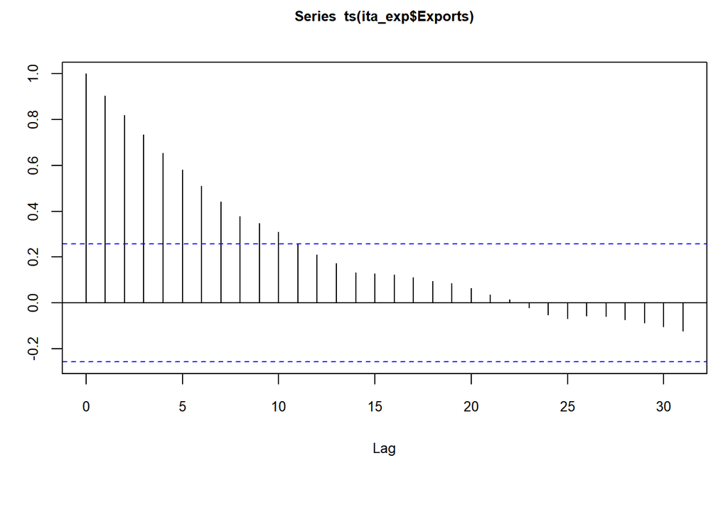

```r
# Plot the autocorrelation plot to check seasonality
ita_exp<- global_economy %>% filter(Country=="Italy")%>% select(Exports)
par(mar=c(7, 3, 3, 1), cex.lab=0.8, cex.axis=0.8, cex.main=0.8) # graphics
acf(ts(ita_exp$Exports), lag.max = 31) # autocorrelation plot
```

- We check if we can identify seasonality within the data and by looking at the autocorrelation plot we can state that there is no seasonality, which was to be expected given that the data is reported annually.

### 2. Use one of the viewed methods (simple exponential smoothing, Holt, Holt-Winter) which is appropriated to your series. Justify your choice. Comment on your model’s parameter(s). How well does your model fit the data?

Concluding that we can identify a trend in the data, but no seasonality it would be pertinent to use the Holt’s linear trend method (A,N). It includes a forecast equation and two smoothing equations.

$\hat{y}_{t+h|t}=l_t+hb_t$

$l_t= \alpha y_t+(1-\alpha )(l_{t-1}+b_{t-1})$

$b_t= \beta^*(l_t-l_{t-1})+(1-\beta ^*)b_{t-1}$

α is the smoothing parameter for the level and it takes values from 0 to 1.

β* is the smoothing parameter for the trend.

```r
ita_exp_ts <- ts(ita_exp$Exports, start = 1960)
fit1<- holt(ita_exp_ts, initial = "optimal", h=4)
summary(fit1)
```

```
##
## Forecast method: Holt's method
##
## Model Information:
## Holt's method
##
## Call:
##  holt(y = ita_exp_ts, h = 4, initial = "optimal")
##
##   Smoothing parameters:
##     alpha = 0.9485
##     beta  = 1e-04
##
##   Initial states:
##     l = 12.1963
##     b = 0.3366
##
##   sigma:  1.3424
##
##      AIC     AICc      BIC
## 275.5212 276.6751 285.8235
##
## Error measures:
##                        ME     RMSE       MAE        MPE     MAPE     MASE
## Training set -0.008657762 1.295316 0.9336816 -0.2918513 4.469588 0.915687
##                   ACF1
## Training set 0.0375028
##
## Forecasts:
##      Point Forecast    Lo 80    Hi 80    Lo 95    Hi 95
## 2018       31.57466 29.85426 33.29506 28.94354 34.20578
## 2019       31.91124 29.53991 34.28258 28.28460 35.53789
## 2020       32.24783 29.36907 35.12658 27.84515 36.65050
## 2021       32.58441 29.27506 35.89376 27.52319 37.64563
```

We firstly model the time series specifying the initial argument to `optimal`, meaning that the initial values are optimized along with the smoothing parameters using ets.

In this case we did not specify the alpha value, therefore it has been estimated, same goes for the beta parameter. Respectively, they amount to 0.9485 and 1*10^(-04). The alpha is the smoothing parameter for the level, it being close to 1 indicates that the estimation process is very responsive to each new observation.

The optimized initials states $l_t$ and$b_t$, which in this order give an estimate of the local level of the data generating process at time t and the estimate of the trend at time t.

Following there are the model selection criteria, Akaike’s IC, AIC corrected for small sample bias, and finally the Bayesian Information Criterion. When we will confront many different model we will look for the process with the lowest values.Usually these three indices point in the same direction for model selection, maybe BIC will favour a more simpler method.

The scale dependent error measures MAE and RMSE, tells respectively that on average the errors magnitude is of 0.9336816 and the fitted model will vary from the true process by 1.295316.

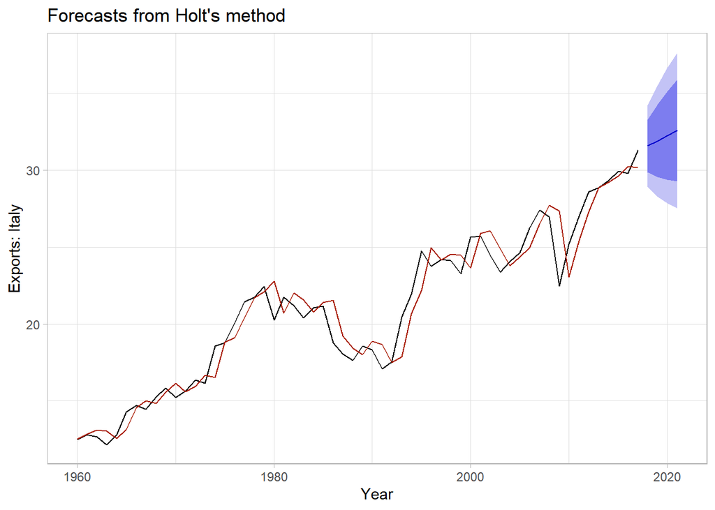

```r
autoplot(fit1) +
  autolayer(fitted(fit1), color = "#A91D01")+
  ylab("Exports: Italy") + xlab("Year")+ theme_light()
```

By simply judging on graphical we can see that the estimated process moves very closely to the true time series. In this case we have seen that the data has had a lot of ups and owns, which will probably influence the future exports as well.So maybe trying a damped method were the trend is reduced within long run horizons, would be appropriate.

##### We try with the Damped Holt’s Method (Ad, N):

$\hat{y}_{t+h|t}=l_t+\phi b_{t-1}\\l_t=\alpha y_t+(1-\alpha)(l_{t-1}+\phi b_{t-1})\\b_t=\beta^*(l_t-l_{t-1})+(1-\beta^*)\phi b_{t-1}$

The method introduce a parameter phi which indicates how the trend the forecast will flatten through time.

```r
fit2<- holt(ita_exp_ts, initial = "optimal", h=4, damped=TRUE)
summary(fit2)
```

```
##
## Forecast method: Damped Holt's method
##
## Model Information:
## Damped Holt's method
##
## Call:
##  holt(y = ita_exp_ts, h = 4, damped = TRUE, initial = "optimal")
##
##   Smoothing parameters:
##     alpha = 0.9962
##     beta  = 1e-04
##     phi   = 0.98
##
##   Initial states:
##     l = 11.4958
##     b = 0.4297
##
##   sigma:  1.3642
##
##      AIC     AICc      BIC
## 278.3009 279.9479 290.6635
##
## Error measures:
##                      ME     RMSE       MAE       MPE     MAPE      MASE
## Training set 0.09104357 1.304051 0.9654412 0.1556479 4.625439 0.9468345
##                     ACF1
## Training set 0.001007716
##
## Forecasts:
##      Point Forecast    Lo 80    Hi 80    Lo 95    Hi 95
## 2018       31.42233 29.67407 33.17060 28.74860 34.09607
## 2019       31.55071 29.08286 34.01855 27.77646 35.32495
## 2020       31.67651 28.65579 34.69723 27.05672 36.29630
## 2021       31.79980 28.31269 35.28690 26.46673 37.13287
```

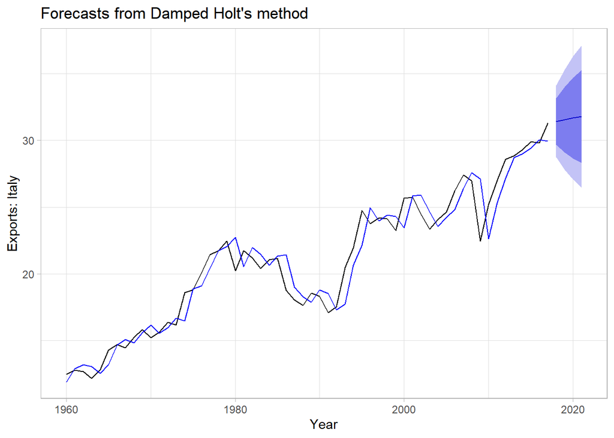

```r
autoplot(fit2) +
  autolayer(fitted(fit2), color = "blue")+
  ylab("Exports: Italy") + xlab("Year")+ theme_light()
```

The alpha parameter is higher with the damped method making the model more responsive to new observations. Because we are utilizing a damped holt’s model the process comprehends the phi parameter which is the value of the damping parameter. The value of it is 0.98 (the maximum allowed by the model) which is very close to 1 and indicates that the model is not different to a regular non damped process.

In comparison the first fitted model we have used to build a forecast presents lower Model selection measures, and also lower error measures. All in all the first model `fit1` seems to do a better job even if they are very close in performance. To be noted is that we have not used the damped methods to compute a long run forecast, not exploiting its full potential.

### 3. Run model with different values of the parameter(s). Plot it against parameter(s) values. How each parameter does impact the forecast?

So far we have let the function do the work in terms of estimating the optimal alpha and beta parameters.

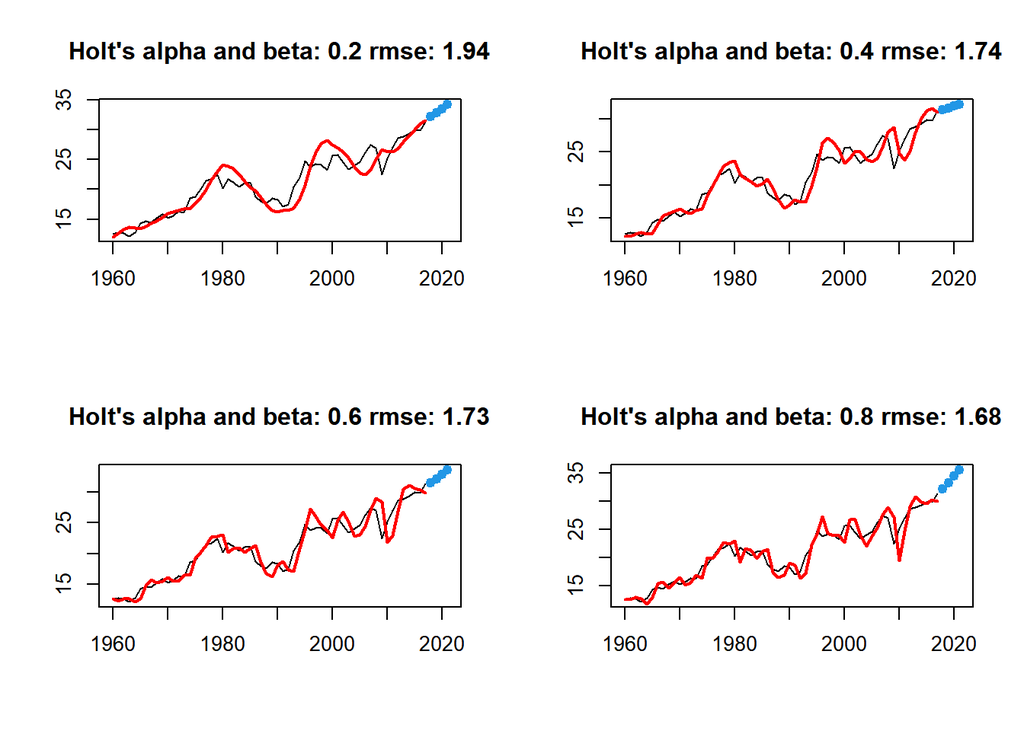

```r
par(mfrow=c(2,2)) # graphics

for(i in seq(0.2,0.8,0.2)){
  model.holt = holt(ita_exp_ts, alpha = i, beta = i,initial = "optimal", h = 4)

  alpha_beta_txt = paste("Holt's alpha and beta:", i, sep=" ")
  rmse = round(sqrt(sum(model.holt$residuals^2)/length(model.holt$residuals)),2)
  rmse_txt = paste("rmse:", rmse, sep=" ")
  title_txt = paste(alpha_beta_txt, rmse_txt, sep =" ")

  plot(model.holt, main = title_txt, PI=FALSE)
  lines(fitted(model.holt), lwd=2, col="red")
  }
```

### 4. Provide forecast for 5 steps ahead. Does your prediction look good? Please, explain.

```r
# Update the parameter h
fit5<- holt(ita_exp_ts, initial = "optimal", h=5)
summary(fit5)
```

```
##
## Forecast method: Holt's method
##
## Model Information:
## Holt's method
##
## Call:
##  holt(y = ita_exp_ts, h = 5, initial = "optimal")
##
##   Smoothing parameters:
##     alpha = 0.9485
##     beta  = 1e-04
##
##   Initial states:
##     l = 12.1963
##     b = 0.3366
##
##   sigma:  1.3424
##
##      AIC     AICc      BIC
## 275.5212 276.6751 285.8235
##
## Error measures:
##                        ME     RMSE       MAE        MPE     MAPE     MASE
## Training set -0.008657762 1.295316 0.9336816 -0.2918513 4.469588 0.915687
##                   ACF1
## Training set 0.0375028
##
## Forecasts:
##      Point Forecast    Lo 80    Hi 80    Lo 95    Hi 95
## 2018       31.57466 29.85426 33.29506 28.94354 34.20578
## 2019       31.91124 29.53991 34.28258 28.28460 35.53789
## 2020       32.24783 29.36907 35.12658 27.84515 36.65050
## 2021       32.58441 29.27506 35.89376 27.52319 37.64563
## 2022       32.92099 29.23088 36.61111 27.27745 38.56454
```

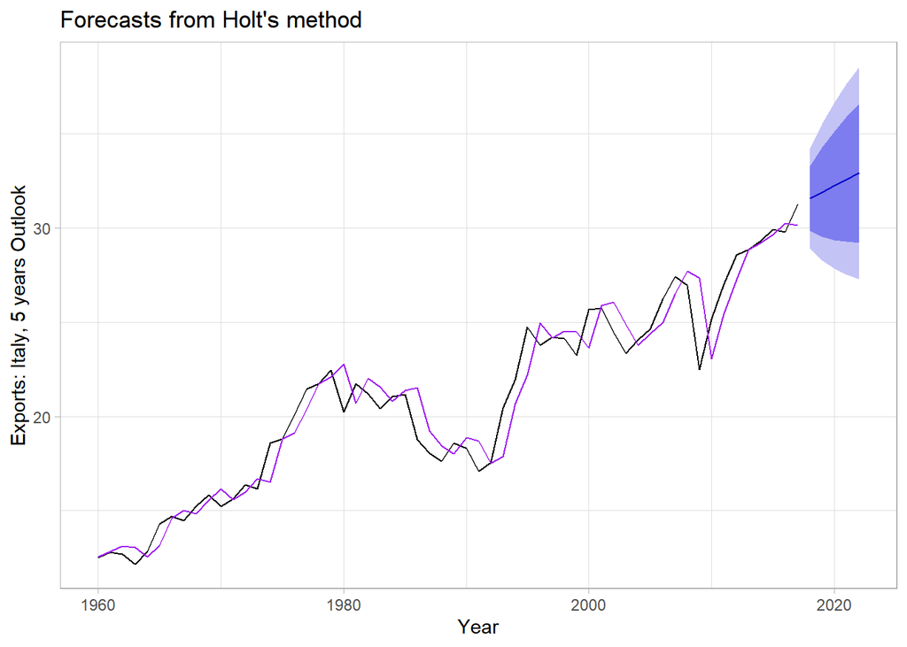

```r
autoplot(fit5) +
  autolayer(fitted(fit5), color = "purple")+
  ylab("Exports: Italy, 5 years Outlook") + xlab("Year")+ theme_light()
```

The model parameters have not changed much from the initial model we fitted. The forecast is plotted out with the 80% and 95% confidence intervals, they f course get larger as time progresses because of the added uncertainty. The forecast is positively trending, which is good enough given that the 2020 exogenous shock could have not been predicted.

###* Optional. Bonus task. Repeat your analysis for another country applying different method.

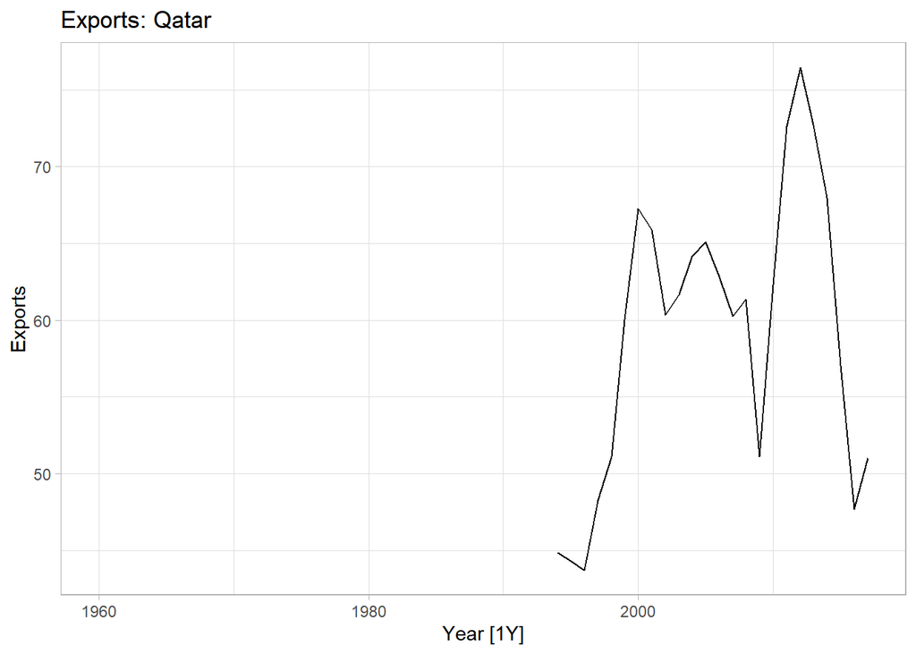

```r
global_economy%>% filter(Country=="Qatar")%>%
  autoplot(Exports)+
  labs(title="Exports: Qatar")+ theme_light()
```

The exports data for Qatar starts during mid 90s and the steep increase is attributable to the start of development of its its natural gas resources in the mid-1990s. The data is annual so no seasonality can really be observed.

#### Estimation of a SES and Holt’s model:

The series does not seem to display trend, yet we model both models and compare the outputs.

```r
qatar_exp<- global_economy %>% filter(Country=="Qatar")%>% select(Exports)
qt_exp_ts <- ts(qatar_exp$Exports, start = 1960)

# Simple Exponential Smoothing
fitbn_1<- ses(qt_exp_ts, initial = "optimal", h=5)
summary(fitbn_1)
```

```
##
## Forecast method: Simple exponential smoothing
##
## Model Information:
## Simple exponential smoothing
##
## Call:
##  ses(y = qt_exp_ts, h = 5, initial = "optimal")
##
##   Smoothing parameters:
##     alpha = 0.9999
##
##   Initial states:
##     l = 44.8697
##
##   sigma:  6.1097
##
##      AIC     AICc      BIC
## 167.0590 168.2590 170.5931
##
## Error measures:
##                     ME     RMSE      MAE        MPE     MAPE      MASE
## Training set 0.2572073 5.849573 4.580987 0.03851382 7.755989 0.9584066
##                   ACF1
## Training set 0.3070303
##
## Forecasts:
##      Point Forecast    Lo 80    Hi 80    Lo 95    Hi 95
## 2018        51.0421 43.21223 58.87196 39.06734 63.01685
## 2019        51.0421 39.96954 62.11465 34.10809 67.97610
## 2020        51.0421 37.48127 64.60292 30.30260 71.78159
## 2021        51.0421 35.38353 66.70066 27.09439 74.98980
## 2022        51.0421 33.53538 68.54881 24.26788 77.81631
```

```r
#Holt Model
fitbn_2<- holt(qt_exp_ts, initial = "optimal", h=5)
summary(fitbn_2)
```

```
##
## Forecast method: Holt's method
##
## Model Information:
## Holt's method
##
## Call:
##  holt(y = qt_exp_ts, h = 5, initial = "optimal")
##
##   Smoothing parameters:
##     alpha = 0.9999
##     beta  = 1e-04
##
##   Initial states:
##     l = 40.1961
##     b = 1.482
##
##   sigma:  6.5717
##
##      AIC     AICc      BIC
## 172.2704 175.6038 178.1607
##
## Error measures:
##                     ME     RMSE      MAE       MPE     MAPE      MASE      ACF1
## Training set -1.030392 5.999085 4.743396 -2.098071 8.186784 0.9923848 0.2963707
##
## Forecasts:
##      Point Forecast    Lo 80    Hi 80    Lo 95    Hi 95
## 2018       52.52171 44.09978 60.94364 39.64148 65.40195
## 2019       54.00126 42.09109 65.91143 35.78622 72.21629
## 2020       55.48080 40.89349 70.06811 33.17144 77.79016
## 2021       56.96034 40.11573 73.80496 31.19872 82.72196
## 2022       58.43989 39.60622 77.27355 29.63628 87.24349
```

Alpha is very close to 1 for both models.

According to the Model Selections models, the best performing process is the originated from the SES estimation. The Error Measures point to the same conclusions.

The SES model seem to be the best choice, because it does not model trend within the data which seems to be missing from the series.

The forecast for the SES model is computed as $\hat{y}_{t+h|t}=l_t$ and the smoothing equation is $l_t=\alpha y_t + (1-\alpha)l_{t-1}$ giving the estimated level of the series at each time t.

The forecasts generated by simple exponential smoothing are flat:

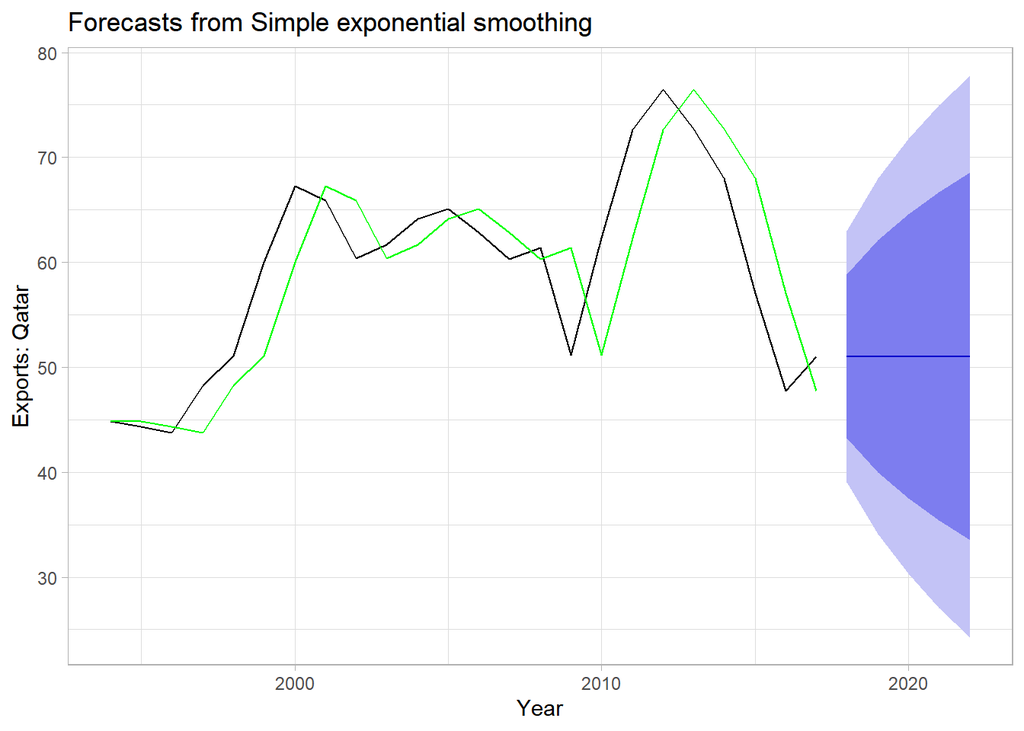

```r
autoplot(fitbn_1) +
  autolayer(fitted(fitbn_1), color = "green")+
  ylab("Exports: Qatar") + xlab("Year")+ theme_light()
```

The h=5 forecast takes the same value as the last level component, which makes sense we are not considering any trend nor seasonality within the process.

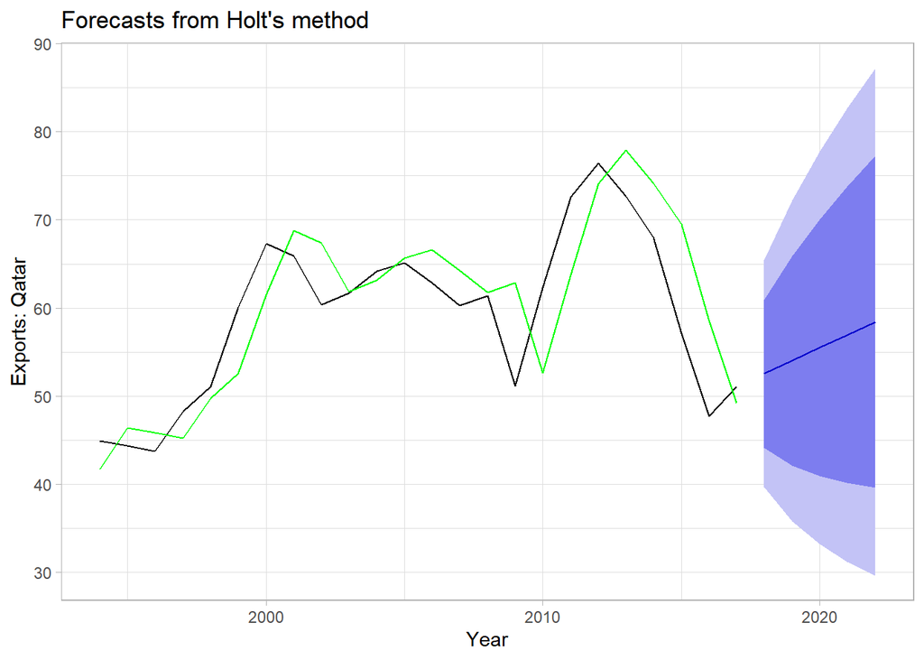

```r
# Holt's method
autoplot(fitbn_2) +
  autolayer(fitted(fitbn_2), color = "green")+
  ylab("Exports: Qatar") + xlab("Year")+ theme_light()
```

For visual comparison we have plotted out the Holt’s method forecast as well, and in fact we can observe how the trend component is incorporated in the prediction.